# Machine Learning Final Project

John McConnell

June 10, 2017

This is the final project for the Practical Machine Learning session of the Johns Hopkins University Data Science Specialization.

# Background

Using devices such as Jawbone Up, Nike FuelBand, and Fitbit it is now possible to collect a large amount of data about personal activity relatively inexpensively. These type of devices are part of the quantified self movement - a group of enthusiasts who take measurements about themselves regularly to improve their health, to find patterns in their behavior, or because they are tech geeks. One thing that people regularly do is quantify how much of a particular activity they do, but they rarely quantify how well they do it. In this project, your goal will be to use data from accelerometers on the belt, forearm, arm, and dumbell of 6 participants. They were asked to perform barbell lifts correctly and incorrectly in 5 different ways. More information is available from the website here: http://groupware.les.inf.puc-rio.br/har (see the section on the Weight Lifting Exercise Dataset).

## Load Datasets

```r
training_pml_csv = read.csv("pml-training.csv",na.strings = c("NA","#DIV/0!",""))
testing_pml_csv = read.csv("pml-testing.csv",na.strings = c("NA","#DIV/0!",""))
dim(training_pml_csv)
```

```
## [1] 19622   160
```

## Do exploratory work on the data to understand the data.

```r
colnames(training_pml_csv)
```

```
##   [1] "X"                        "user_name"
##   [3] "raw_timestamp_part_1"     "raw_timestamp_part_2"
##   [5] "cvtd_timestamp"           "new_window"
##   [7] "num_window"               "roll_belt"
##   [9] "pitch_belt"               "yaw_belt"
##  [11] "total_accel_belt"         "kurtosis_roll_belt"
##  [13] "kurtosis_picth_belt"      "kurtosis_yaw_belt"
##  [15] "skewness_roll_belt"       "skewness_roll_belt.1"
##  [17] "skewness_yaw_belt"        "max_roll_belt"
##  [19] "max_picth_belt"           "max_yaw_belt"
##  [21] "min_roll_belt"            "min_pitch_belt"
##  [23] "min_yaw_belt"             "amplitude_roll_belt"
##  [25] "amplitude_pitch_belt"     "amplitude_yaw_belt"
##  [27] "var_total_accel_belt"     "avg_roll_belt"
##  [29] "stddev_roll_belt"         "var_roll_belt"
```

[output cut: 65 more lines]

```r
str(training_pml_csv)
```

```
## 'data.frame':    19622 obs. of  160 variables:
##  $ X                       : int  1 2 3 4 5 6 7 8 9 10 ...
##  $ user_name               : Factor w/ 6 levels "adelmo","carlitos",..: 2 2 2 2 2 2 2 2 2 2 ...
##  $ raw_timestamp_part_1    : int  1323084231 1323084231 1323084231 1323084232 1323084232 1323084232 1323084232 1323084232 1323084232 1323084232 ...
##  $ raw_timestamp_part_2    : int  788290 808298 820366 120339 196328 304277 368296 440390 484323 484434 ...
##  $ cvtd_timestamp          : Factor w/ 20 levels "02/12/2011 13:32",..: 9 9 9 9 9 9 9 9 9 9 ...
##  $ new_window              : Factor w/ 2 levels "no","yes": 1 1 1 1 1 1 1 1 1 1 ...
##  $ num_window              : int  11 11 11 12 12 12 12 12 12 12 ...
##  $ roll_belt               : num  1.41 1.41 1.42 1.48 1.48 1.45 1.42 1.42 1.43 1.45 ...
##  $ pitch_belt              : num  8.07 8.07 8.07 8.05 8.07 8.06 8.09 8.13 8.16 8.17 ...
##  $ yaw_belt                : num  -94.4 -94.4 -94.4 -94.4 -94.4 -94.4 -94.4 -94.4 -94.4 -94.4 ...
##  $ total_accel_belt        : int  3 3 3 3 3 3 3 3 3 3 ...
##  $ kurtosis_roll_belt      : num  NA NA NA NA NA NA NA NA NA NA ...
##  $ kurtosis_picth_belt     : num  NA NA NA NA NA NA NA NA NA NA ...
##  $ kurtosis_yaw_belt       : logi  NA NA NA NA NA NA ...
```

[output cut: 86 more lines]

## Prediction Variable - classe

Now gather some information about the prediction variable classe. According to the website the classe variable has five possible values:

Class A - exactly according to the specification Class B - technique error: throwing the elbows to the front Class C - technique error: lifting the dumbbell only halfway Class D - technique error: lowering the dumbbell only halfway Class E - technique error: throwing the hips to the front

What we are trying to predict is whether the classe predicted by the model matches the model. So, do the features (columns) correctly predict the way the person was doing the exercise?

```r
summary(training_pml_csv$classe)
```

```
##    A    B    C    D    E
## 5580 3797 3422 3216 3607
```

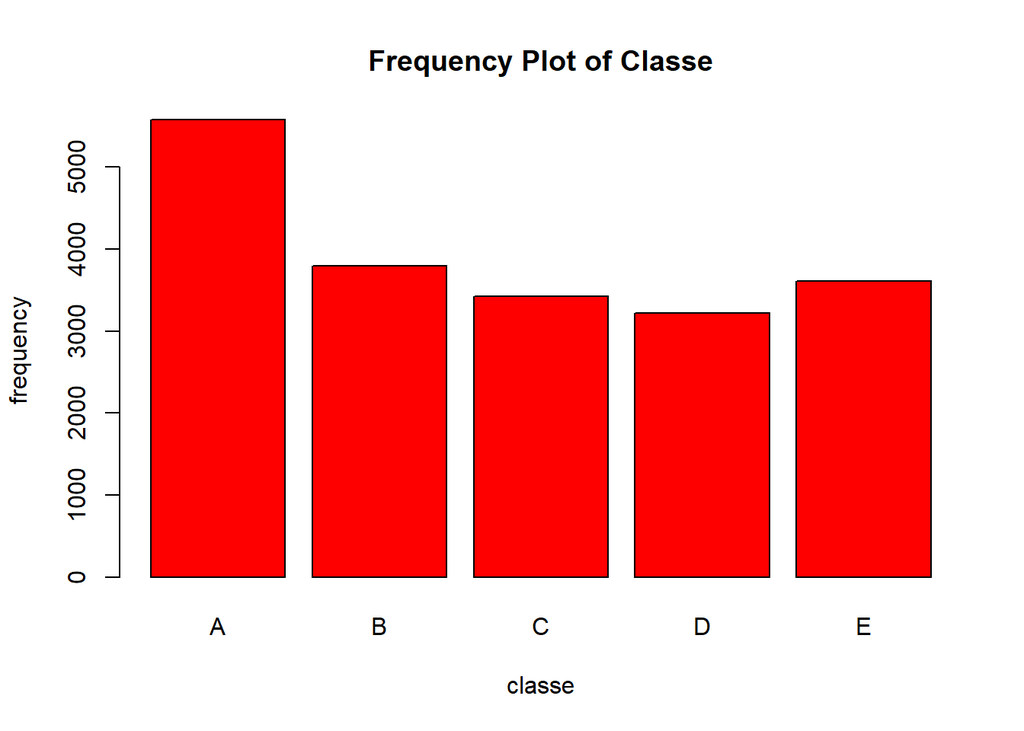

```r
plot(training_pml_csv$classe,main="Frequency Plot of Classe",xlab="classe",ylab="frequency",col="red")
```

## Load the needed packages!

```r
library(randomForest)
library(e1071)
library(caret)
set.seed(1701)
```

## Cleanup/Reduction of Features

The dataset has 160 features/columns which is WAY to many to build a prediction model on. We will now reduce the number of columns. First, we will remove the first 7 columns as they will not provide any value to the model building. Second we will remove any columns that have missing values.

```r
clean_training_pml = training_pml_csv[,-(1:7)]
dim(clean_training_pml)
```

```
## [1] 19622   153
```

```r
clean_testing_pml = testing_pml_csv[,-(1:7)]
dim(clean_testing_pml)
```

```
## [1]  20 153
```

```r
clean_training_pml_noNA = clean_training_pml[,colSums(is.na(clean_training_pml))==0]
clean_testing_pml_noNA = clean_testing_pml[,colSums(is.na(clean_testing_pml))==0]

dim(clean_training_pml_noNA)
```

```
## [1] 19622    53
```

```r
dim(clean_testing_pml_noNA)
```

```
## [1] 20 53
```

## Cross validation

We have now eliminated 100 features (columns) which would not help the model building. With the 53 remaining features we can begin to prep for cross- valdiation.

```r
sub_samples = createDataPartition(y=clean_training_pml_noNA$classe,p=0.8,list=FALSE)
trainingSet = clean_training_pml_noNA[sub_samples,]
testingSet = clean_training_pml_noNA[-sub_samples,]
dim(trainingSet)
```

```
## [1] 15699    53
```

```r
dim(testingSet)
```

```
## [1] 3923   53
```

## Model Creation - RandoForest

Now create the model using randomforest as the method.

```r
modelPMLrf = randomForest(classe ~ ., data=trainingSet,method="class")

predictionPMLrf = predict(modelPMLrf,testingSet,type="class")
```

## Analysis

Now do a confusion matrix to interpret the model run

```r
confusionMatrix(predictionPMLrf, testingSet$classe)
```

```
## Confusion Matrix and Statistics
##
##           Reference
## Prediction    A    B    C    D    E
##          A 1116    2    0    0    0
##          B    0  755    4    0    0
##          C    0    2  680    7    1
##          D    0    0    0  636    2
##          E    0    0    0    0  718
##
## Overall Statistics
##
##                Accuracy : 0.9954
##                  95% CI : (0.9928, 0.9973)
##     No Information Rate : 0.2845
##     P-Value [Acc > NIR] : < 2.2e-16
##
##                   Kappa : 0.9942
##  Mcnemar's Test P-Value : NA
##
## Statistics by Class:
##
##                      Class: A Class: B Class: C Class: D Class: E
## Sensitivity            1.0000   0.9947   0.9942   0.9891   0.9958
## Specificity            0.9993   0.9987   0.9969   0.9994   1.0000
## Pos Pred Value         0.9982   0.9947   0.9855   0.9969   1.0000
## Neg Pred Value         1.0000   0.9987   0.9988   0.9979   0.9991
## Prevalence             0.2845   0.1935   0.1744   0.1639   0.1838
## Detection Rate         0.2845   0.1925   0.1733   0.1621   0.1830
## Detection Prevalence   0.2850   0.1935   0.1759   0.1626   0.1830
## Balanced Accuracy      0.9996   0.9967   0.9955   0.9943   0.9979
```

## Final Predictions on Testing Set

The results are very encouraging! Now run the model on the actual test set!

```r
finalpredictionPMLrf = predict(modelPMLrf, clean_testing_pml_noNA ,type="class")

finalpredictionPMLrf
```

```
##  1  2  3  4  5  6  7  8  9 10 11 12 13 14 15 16 17 18 19 20
##  B  A  B  A  A  E  D  B  A  A  B  C  B  A  E  E  A  B  B  B
## Levels: A B C D E
```